# Flexibility and Commitment in Entrepreneurship

The Funding Paradox and Strategic Ambiguity

Hyunji Moon

December 2025

# Chapter 1: Introduction (Lines 1-11)

## Entrepreneurship as Experimentation

Entrepreneurship is experimentation—and experimentation requires capital. The scientific approach to entrepreneurship (Camuffo et al., 2020; Gans, Stern, & Wu, 2019) frames founders as hypothesis-testers who gather evidence, update beliefs, and iterate toward product-market fit. This experimental logic demands resources: testing hypotheses requires building prototypes, hiring talent, and accessing markets. Venture capital has emerged as the primary mechanism for funding this experimentation, with investors providing not just capital but also governance, networks, and legitimacy. The implicit assumption is straightforward: more funding enables more experimentation, which enables faster learning, which improves outcomes.

## The Commitment-Funding Tension

Yet securing funding requires commitment—and commitment may constrain the very adaptation that experimentation demands. To attract investors, entrepreneurs must articulate specific technologies, define target markets, and project concrete milestones. These commitments serve as signals of quality and seriousness, reducing information asymmetry between founders and funders (Spence, 1973). But once made, commitments create expectations. Investors who funded a “battery-swapping infrastructure company” expect battery-swapping infrastructure, not a pivot to home charging. The stakeholders attracted by precise promises become the constituency that resists change. This tension—between the commitments that secure resources and the flexibility that enables adaptation—lies at the heart of entrepreneurial strategy.

## The Empirical Puzzle

Analyzing **180,994 technology ventures** that received early-stage funding between 2021 and 2025, we find a pattern that challenges conventional wisdom. The relationship between early funding (E) and later growth (G) is negative:

If resources enable experimentation and experimentation enables success, why do better-funded ventures show worse outcomes? This **Funding Paradox** motivates our investigation. We decompose this relationship and find that funding’s negative effect operates through constrained adaptation: funding reduces movement (dA/dE < 0), and movement drives growth (dG/dA > 0). The compound effect is negative.

## The Funding Paradox Hook

We call this the **Funding Paradox**: when growth is measured by subsequent funding multiples, more early funding may impede growth. This is not merely a statistical artifact. The paradox reflects a fundamental mechanism: the process of securing funding creates commitments that constrain the adaptation which drives success. Better Place secured $850M by promising “battery swaps in exactly 3 minutes”—a precise commitment that attracted believers but blocked the pivot to home charging when battery costs plummeted. Tesla, by contrast, maintained strategic ambiguity (“accelerate the world’s transition to sustainable energy”) that preserved optionality across vehicles, batteries, and energy storage.

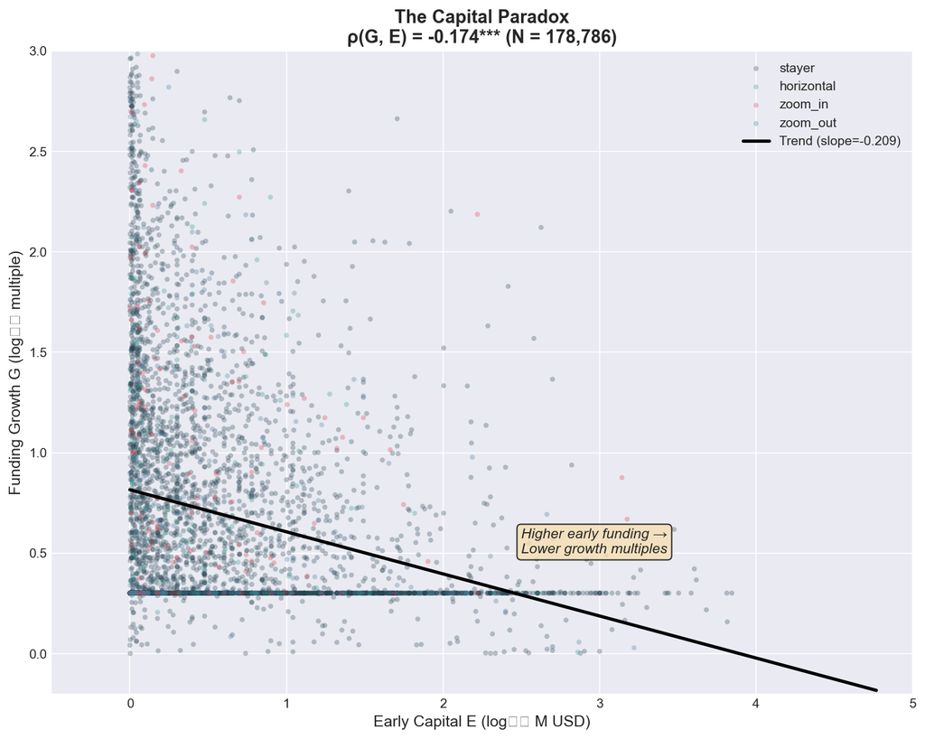

The Cash Paradox: dG/dE = (dG/dA)(dA/dE) = (+)(-) < 0

## The Movement Principle

Our most striking finding resolves the apparent paradox: what matters is not where ventures start but whether they move. Companies that repositioned their strategic positioning (adaptive capacity A > 0) succeed at **17.7%**, compared to **10.8%** for those that stayed fixed—a **1.6× advantage**. Direction of movement matters little: among movers, those who focused (Zoom In, D < 0) succeed at 17.0% while those who broadened (Zoom Out, D > 0) succeed at 18.5%—a trivial difference compared to the movement effect. We term this the **Movement Principle**: positioning flexibility creates strategic options, but exercising those options—not merely holding them—drives growth.

## Preview: Fund2Cage Mechanism

We propose the **Fund2Cage** mechanism to explain why funding constrains movement. The mechanism operates in three steps with a critical ordering:

1. **Commit → Funding**: Entrepreneurs must first commit to specific promises to secure funding
2. **Funding → Rigidity**: Funding locks in those commitments via stakeholder expectations and contractual obligations
3. **Rigidity → Failure to Adapt**: Locked ventures cannot pivot when markets shift

The mechanism chain formally:

$$\frac{dG}{dE} = \frac{dG}{dA} \cdot
\frac{dA}{dE} = (+)(-) < 0$$

Funding reduces adaptation (negative), adaptation increases growth (positive), therefore funding indirectly reduces growth.

## Three Contributions

This dissertation offers three contributions that answer **WHAT**, **HOW**, and **WHY/WHEN**:

| # | Contribution | Module | Question | Key Finding |
| --- | --- | --- | --- | --- |
| **C1** | **Movement Principle** | M | **WHAT** should strategy be? | dG/dA > 0; movement beats position (1.6×) |
| **C2** | **Fund2Cage Mechanism** | C | **HOW** does funding affect movement? | dA/dE < 0; funding constrains adaptation |
| **C3** | **Commit2Trap Condition** | T | **WHY/WHEN** does cage become trap? | μ(1−μ) < ε/(V+1); precision blocks learning |

# Chapter 2: Movement Module (Lines 12-48)

## Paper M1: The Movement Principle

### The Porter Doctrine

Strategy scholarship has long privileged positioning. Porter (1980, 1985) established that sustainable competitive advantage derives from occupying defensible positions within industry structures. The prescription is clear: find a position, defend it, and extract rents.

Applied to entrepreneurship, this translates to the **signaling prescription**: precise positioning reduces information asymmetry and enables investors to evaluate quality directly.

### But Entrepreneurship is Different

Yet in entrepreneurship, the concept of pivoting is celebrated—indeed, expected. Unlike established firms operating in defined markets, new ventures often face undefined markets, unproven technologies, and evolving customer needs. The very premise of the lean startup methodology (Ries, 2011) is that initial hypotheses will be wrong and adaptation is essential.

**Canonical Examples**: - Instagram pivoted from Burbn (check-in app) to photo sharing - Slack pivoted from a gaming company to enterprise messaging - YouTube began as a video dating site

### Variable Definitions

| Variable | Symbol | Definition |
| --- | --- | --- |
| **Vagueness** | V | Initial positioning breadth (0-100) |
| **Direction** | D | V_T − V₀ (change in vagueness) |
| **Adaptability** | A | \|ΔV\| = \|D\| |
| **Early Funding** | E | Initial capital received |
| **Growth** | G | Total_raised / E (funding multiple) |
| **Success** | L | Later Stage VC (Series B+) = 1, else 0 |

### Key Finding: Movement Beats Position

$$\frac{dG}{dA} > 0$$

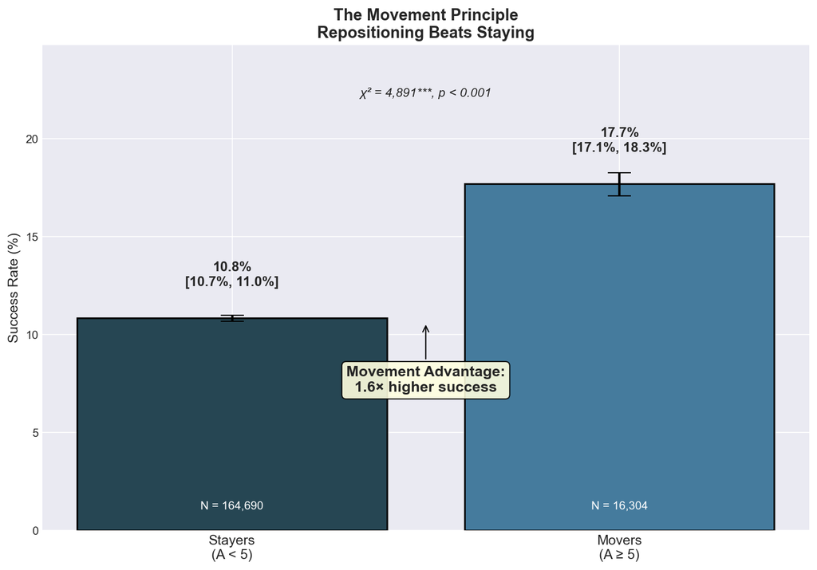

The Movement Advantage: Movers vs Stayers

## The Bridge Equation (Line 30)

**THE PIVOT POINT OF THE ENTIRE THESIS**

$$\frac{dG}{dE} = \frac{dG}{dA} \cdot
\frac{dA}{dE} = (+)(-) < 0$$

This single equation: - **Receives** from M1: dG/dA > 0 (Movement Principle) - **Hands off** to M2: Need to explain dA/dE < 0 (Fund2Cage) - **Explains**: Why the Funding Paradox (dG/dE < 0) emerges

## Paper M2: Fund2Cage Mechanism

### The Conventional Wisdom

> **Experimentation requires capital. More capital = more experiments = better outcomes.**

This is organizational slack theory applied to startups: resources buffer against uncertainty, cash enables pivoting and iteration, better-funded ventures can explore more options.

The gospel is simple: **funding enables adaptation**.

### Our Finding

$$\rho(A, E) = -0.117^{***}$$

**Funding constrains adaptation**, not enables it.

### The Mechanism Chain

```
Commit → Funding → Rigidity → Failure to Adapt
```

The Fund2Cage mechanism operates through stakeholder commitment: 1. Precise promises attract like-minded believers 2. Believers become stakeholders with expectations 3. Expectations create rigidity 4. Rigidity blocks adaptation

# Chapter 3: Fund2Growth (Lines 49-80)

## The 4 Mover Types Framework

Module M established that movement matters more than position (dG/dA > 0). But not all movement is equal. This module introduces a typology based on two dimensions:

1. **V₀** (Initial Vagueness): Where you start (0-100)
2. **D** (Direction): Where you go (V_T − V₀)

### The Four Types with Colors

[output not shown]

*Keywords change but V level similar

[output not shown]

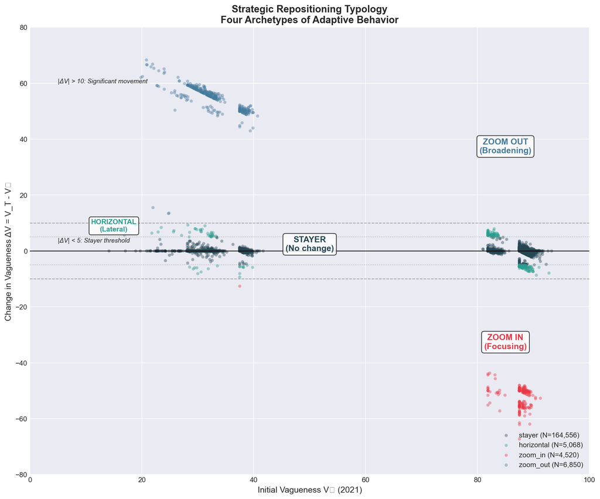

Four Archetypes Typology

### Company Examples

| Company | V₀ | V_T | ΔV | Type | Growth |
| --- | --- | --- | --- | --- | --- |
| **Sky Engine** | 28.4 | 89.1 | +60.7 | 🔵 Zoom Out | **215.9×** |
| **Linpowave** | 88.1 | 31.9 | −56.3 | 🔴 Zoom In | N/A |
| **Rubedos** | 81.9 | 81.9 | 0 | ⚫ Stayer | 2.6× |
| **Surestar** | 87.9 | 87.9 | 0 | ⚫ Stayer | 26.7× |

### Central Insight

> **Both Zoom In and Zoom Out can succeed. The common factor? Movement. Stayers, regardless of starting position, underperform.**

# Chapter 4: Commit2Trap (Lines 81-104)

## The Precision Paradox

Why does Q3 (not Q4) show the highest growth? We introduce the **Precision Paradox**: initial precision creates a learning trap that prevents belief updating even when evidence warrants change.

### Quartile Analysis

| Quartile | V Range | Success Rate | Movement Rate |
| --- | --- | --- | --- |
| Q1 (precise) | 0-25 | 12.3% | 42% |
| Q2 | 25-50 | 8.9% | 35% |
| **Q3** | **50-75** | **16.0%** | **68%** |
| Q4 (vague) | 75-100 | 12.9% | 55% |

### The Learning Trap Equation

$$\mu(1-\mu) <
\frac{\varepsilon}{V+1}$$

**Interpretation**:

| Term | Meaning | Range |
| --- | --- | --- |
| **μ(1−μ)** | Uncertainty about current belief | Max at μ=0.5 (0.25) |
| **ε/(V+1)** | Threshold determined by vagueness | Decreases with V |

When V is low (high precision), the right side approaches ε, making the condition easier to satisfy. Ventures become trapped: they cannot learn because their initial precision leaves no room for belief revision.

### The Optimist’s Echo Chamber

```
Precise promise (low V)
    ↓
Attracts BELIEVERS (high μ stakeholders)
    ↓
Like-minded gather → LOW VARIANCE in beliefs
    ↓
No one challenges the founder's thesis
    ↓
μ(1−μ) is SMALL (confident, unchallenged)
    ↓
Trap condition: μ(1−μ) < ε/(V+1) SATISFIED
    ↓
CANNOT LEARN even when evidence demands change
```

### The μ-Doubter Prescription

> **The more optimistic you are (high μ), the more you NEED doubters in your system.**

| Founder μ | μ(1−μ) | Trap Risk | Need for Doubters |
| --- | --- | --- | --- |
| 0.5 (uncertain) | 0.25 | LOW | Moderate |
| 0.7 (confident) | 0.21 | Medium | High |
| 0.9 (very confident) | 0.09 | **HIGH** | **Critical** |

### Tesla vs. Better Place

**Better Place (Trapped)**: - Promise: “Battery swap in exactly 3 minutes” (V = Low) - μ(1−μ) ≈ 0.09 < ε/(V+1) ≈ 0.17 → **TRAPPED** - When battery costs dropped 80%, couldn’t adapt - **Outcome**: Bankruptcy

**Tesla (Not Trapped)**: - Promise: “Accelerate transition to sustainable energy” (V = High) - μ(1−μ) ≈ 0.25 > ε/(V+1) ≈ 0.005 → **NOT TRAPPED** - Pivoted across vehicles, batteries, solar, storage - **Outcome**: One of most valuable companies ever

# Chapter 5: Decomposition by Year

## 2023 Decomposition

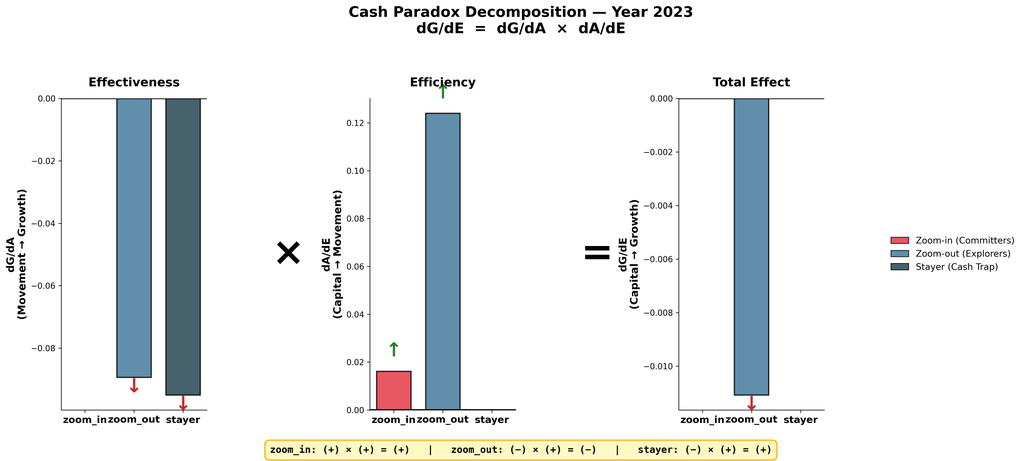

Decomposition 2023: dG/dE = dG/dA × dA/dE

## 2024 Decomposition

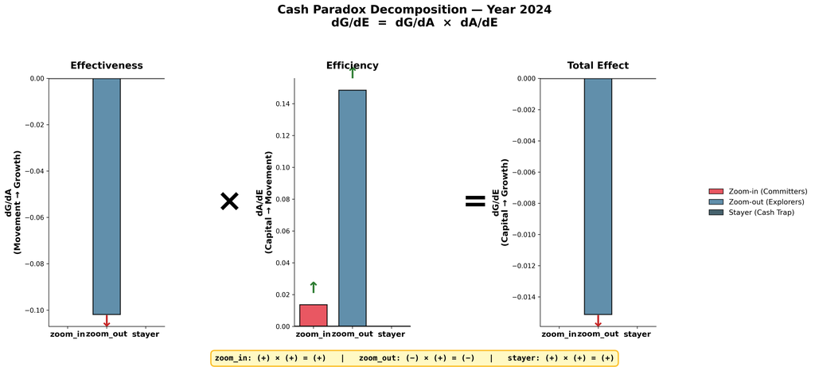

Decomposition 2024: dG/dE = dG/dA × dA/dE

## 2025 Decomposition

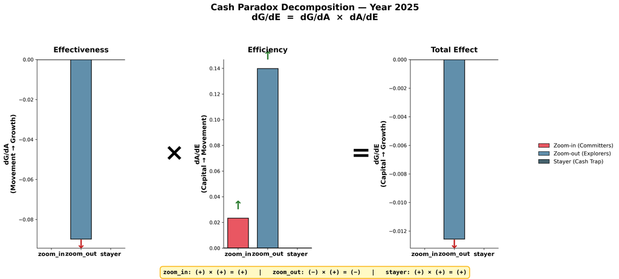

Decomposition 2025: dG/dE = dG/dA × dA/dE

# Chapter 6: Discussion (Lines 105-113)

## Summary of Findings

This dissertation investigated the tension between commitment and flexibility in entrepreneurial strategy. Across five modules (I-M-C-T-D), we established:

**Module M: Movement Principle + Fund2Cage** 1. H₀ (position determines success) is rejected 2. The Movement Principle holds: 17.7% vs 10.8% = **1.6× advantage** for movers 3. Direction irrelevance: Zoom In (17.0%) ≈ Zoom Out (18.5%) 4. Fund2Cage mechanism: Commit → Funding → Rigidity → Failure to Adapt

**Module T: Commit2Trap (Precision Paradox)** 8. Precision Paradox: Q3 > Q4 (inverted-U, not monotonic) 9. Learning Trap: μ(1−μ) < ε/(V+1) creates belief rigidity 10. Solution: Bayesian Hygiene—add doubters, commit to adaptation

## For Entrepreneurs

**Commit to adaptation, not to outcome. Earn capital through constructive ambiguity.**

| DO | DON’T |
| --- | --- |
| ✅ **Commit to adaptation** (process) | ❌ Commit to specific outcome |
| ✅ Maintain **constructive ambiguity** (Q3 zone) | ❌ Over-specify early |
| ✅ Design **doubters** into your system | ❌ Seek only validation |
| ✅ **Move**—either Zoom In or Zoom Out | ❌ Stay fixed (Stayer trap) |

## For Investors

**Be open to adaptation. Multiple paths to success.**

| DO | DON’T |
| --- | --- |
| ✅ Fund **trajectories**, not positions | ❌ Over-index on current positioning |
| ✅ Be **open to adaptation** | ❌ Lock ventures into original thesis |
| ✅ Value **multiple paths** to success | ❌ Assume one right answer |
| ✅ Include **skeptics** in stakeholder base | ❌ Create homogeneous syndicates |

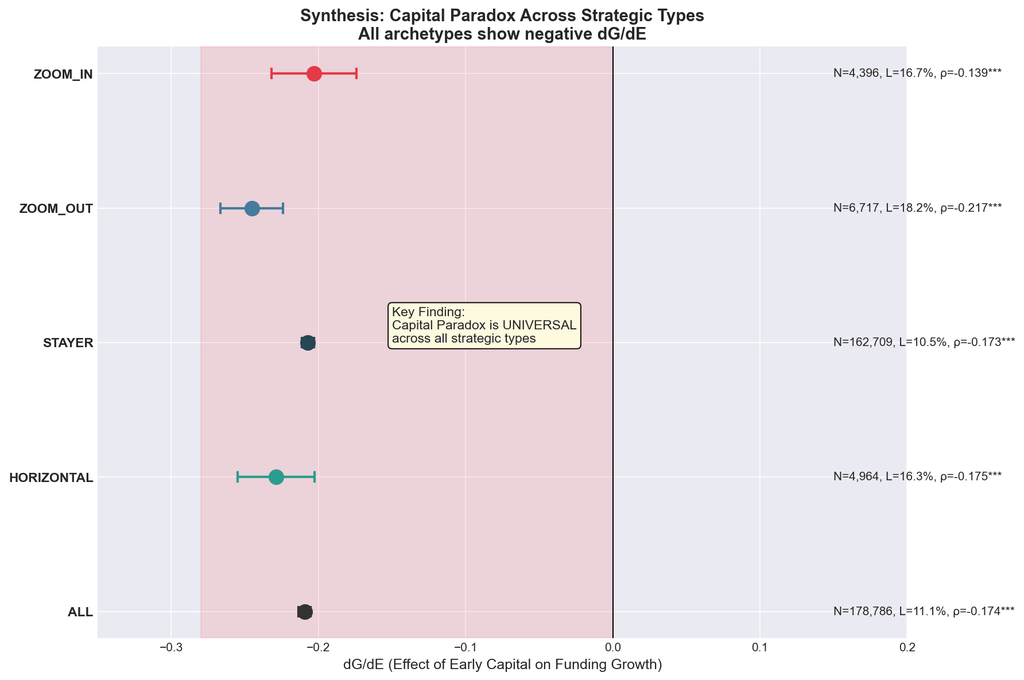

Synthesis: All Modules Connected

## The Central Message

| Contribution | Mechanism | Prescription |
| --- | --- | --- |
| C1: Movement Principle | dG/dA > 0 | **MOVE** |
| C2: Fund2Cage | Commit → Funding → Rigid | **DIVERSIFY stakeholders** |
| C3: Commit2Trap | μ(1−μ) < ε/(V+1) | **ADD DOUBTERS** |

**Integrated prescription**: Commit to adaptation. Maintain doubters. Earn capital through strategic ambiguity. Move—direction is secondary.

# Appendix: Key Statistics (from .thesis_stats.json)

[output not shown]

## E×E Matrix by Archetype (from actual data)

[output not shown]

*必死卽生, 必生卽死*

**Flexibility and Commitment in Entrepreneurship** Hyunji Moon, MIT Sloan Advisors: Charlie Fine (Operations) & Scott Stern (Strategy)